# Programming template for module 01

## Program details

This program serves as a model for your use in the programming assignment of module 01. It reads in data from a text file with comma delimiters, produces a few simple statistics and a simple graph.

This program was written by Steve Simon on 2024-12-18 and is placed in the public domain. You can use it any way that you please.

```r
R.version.string
```

```
[1] "R version 4.3.0 (2023-04-21 ucrt)"
```

```r
Sys.Date()
```

```
[1] "2024-12-26"
```

```r
library(tidyverse)
```

#### Comments on the code

When you use unusual or novel R code, include a brief description.

Let’s describe the code in this chunk in reverse order.

The [library](https://stat.ethz.ch/R-manual/R-devel/library/base/html/library.html) function loads an R library. In this case, it loads the tidyverse library. You should almost always include the tidyverse library. In future programs, you may load other libraries as well.

The [Sys.Date](https://stat.ethz.ch/R-manual/R-devel/library/base/html/Sys.time.html) function places a date-time stamp on your program. This helps you to determine if a particular set of output from R is in need of updating.

[R.version.string](https://stat.ethz.ch/R-manual/R-devel/library/base/html/Version.html) is a scalar that is set by R before your program runs. It is good programming practice to document the version of R that you are using since updates to R may affect your output or even cause your program to fail. This doesn’t happen too often, but it helps insure that your data analysis is reproducible.

The message and warning options are two [execution options](https://quarto.org/docs/computations/execution-options.html) that tell R whether or not to produce a lot of informational output. You definitely want this option set before loading the tidyverse library.

Another execution option is label. Although a label is optional, you should include one for every program chunk. This helps with tracking warning and error messages. Never duplicate a label.

#### Interpretation of the output

For all except the most basic output, include a brief interpretation. Don’t include interpretations for this chunk which provides general information, the second chunk that just provides a glimpse of your data, or the last chunk that saves your data.

## Read aids-cases.csv

```r
aids_cases <- read_csv(
  "../data/aids-cases.csv",
  col_types="nnn")
glimpse(aids-cases)
```

[output not shown]

[output not shown]

#### Comments on the code

I will defer discussion of the read_csv function until a later module.

The [glimpse](https://dplyr.tidyverse.org/reference/glimpse.html) function provides a listing of each variable in a data frame along with the first few values of that variable. It is useful for orienting yourself to the way that your data is organized.

## Compute the range for New South Wales AIDS cases

```r
aids_cases |>
  summarize(
    case_min=min(nsw),
    case_max=max(nsw))
```

```
# A tibble: 1 × 2
  case_min case_max
     <dbl>    <dbl>
1        1      259
```

#### Comments on the code

The [pipe](https://stat.ethz.ch/R-manual/R-devel/library/base/html/pipeOp.html) operator (|>) allows you to apply a series of functions in sequence. It is not really needed for this example, but in more complex settings, it can produce code that is easier to read and maintain.

The [summarize](https://dplyr.tidyverse.org/reference/summarise.html) function produces summary statistics for variables in your data.

## Graph the trend in AIDS cases in New South Wales

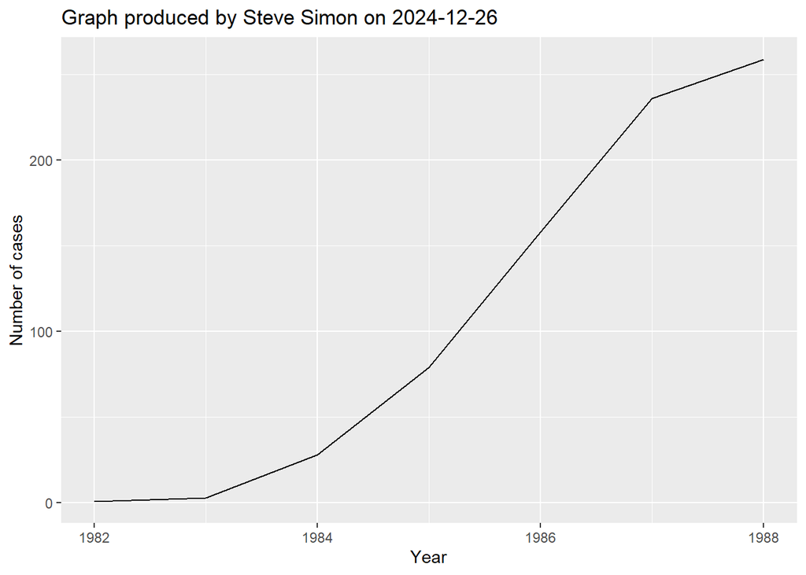

```r
aids_cases |>
  ggplot() +
    aes(yr, nsw) +
    geom_line() +
    xlab("Year") +
    ylab("Number of cases") +
    ggtitle("Graph produced by Steve Simon on 2024-12-26")
```

#### Comments on the code

The ggplot function and all of the functions that follow it are part of the [ggplot2](https://ggplot2.tidyverse.org/) library. We will defer detailed discussion of this library until a later module.

#### Interpretation of the output

There is an increasing trend in AIDS cases in New South Wales over time.

## Save important files for later use

```r
save(
  aids_cases,
  file="../data/aids-cases.RData")
```

#### Comments on the code

The [save] function is optional, but produces a binary file that you can use later. The binary format takes less space and loads substantially faster than re-reading the data from a text file. It also preserves changes that you made, if any, to the data.